# Soluções da Lista de Exercícios 5

Introdução à Ciência de Dados - 2026/1  
Mestrado em Administração

Autor

Prof. Dr. Washington S. da Silva

Data de Publicação

7 de maio de 2026

# Introdução

As respostas abaixo usam **simulação** para ilustrar conceitos de teoria da probabilidade com a linguagem R. Portanto, os valores numéricos obtidos devem ser interpretados como **estimativas**, não como resultados exatos. Com a mesma semente, os resultados são reproduzíveis; com outra semente ou outro número de simulações, os números podem mudar um pouco.

A justificativa conceitual para esse procedimento está relacionada à **lei dos grandes números**: quando repetimos muitas vezes um experimento aleatório nas mesmas condições, médias, proporções e outras estatísticas calculadas a partir dos dados simulados tendem a se aproximar das quantidades teóricas correspondentes, como valores esperados, probabilidades, variâncias, covariâncias e correlações.

Nos exercícios, a função `sample()` é usada para gerar valores pseudoaleatórios de variáveis aleatórias discretas, a partir de valores possíveis e de suas respectivas probabilidades. Em alguns exercícios, também usamos `replicate()` para repetir muitas vezes o mesmo procedimento de simulação e, assim, construir uma distribuição simulada da quantidade de interesse.

A simulação não substitui as propriedades teóricas da probabilidade. Ao contrário, ela ajuda a visualizá-las e interpretá-las. Por isso, ao longo da resolução, os resultados simulados são relacionados a conceitos como valor esperado, frequência relativa, linearidade do valor esperado, valor esperado condicional, covariância, correlação e diversificação.

**NotaComo analisar estas soluções?**

Como ocorre em outras linguagens de programação, um mesmo problema pode ser resolvido de várias maneiras corretas em R. As soluções apresentadas a seguir constituem uma entre diversas estratégias possíveis e foram organizadas para destacar alguns padrões úteis da linguagem, como:

- a **estruturação de simulações** simples com `sample()` e `replicate()`,
- o uso de **funções**,
- o uso de **objetos simples** para resultados numéricos pontuais,
- o uso de `tibbles` quando o próprio resultado é tabular ou quando precisamos empilhar resultados com `bind_rows()`,
- o uso de pipelines com `dplyr` para resumir resultados por grupo, e;
- o emprego de **estruturas de controle** como `if`, `else if` e `else`.

Por isso, em alguns casos, a implementação adotada pode não coincidir exatamente com a forma sugerida no enunciado, embora preserve a lógica do problema e produza os resultados corretos.

```r
# Configuracoes globais do documento ----------------------------

# evita notacao cientifica e deixa os resultados mais legiveis
options(digits = 5, scipen = 999)

# carrega os pacotes usados ao longo da lista
library(tidyverse)
```

## Exercício 1

Vamos simular 10.000 meses de retorno e calcular as medidas pedidas.

```r
# Solução do Exercicio 1 ----------------------------------------

# parametros da simulacao
set.seed(20260507)

retornos_possiveis <- c(0.06, 0.02, -0.01, -0.04)

probabilidades_retorno <- c(0.15, 0.45, 0.25, 0.15)

n_simulacoes <- 10000

# sample() sorteia retornos segundo as probabilidades definidas acima
retornos_simulados <- sample(
  retornos_possiveis,
  size = n_simulacoes,
  replace = TRUE,
  prob = probabilidades_retorno
)

valor_esperado_retorno <- mean(retornos_simulados)
valor_esperado_retorno
```

```
[1] 0.009418
```

```r
variancia_retorno <- var(retornos_simulados)
variancia_retorno
```

```
[1] 0.00088491
```

```r
desvio_padrao_retorno <- sd(retornos_simulados)
desvio_padrao_retorno
```

```
[1] 0.029747
```

```r
# mean(retornos_simulados < 0) calcula a proporcao de meses negativos
probabilidade_retorno_negativo_mensal <- mean(retornos_simulados < 0)
probabilidade_retorno_negativo_mensal
```

```
[1] 0.4023
```

O valor esperado é estimado pela média dos retornos simulados. A variância e o desvio-padrão estimam a dispersão ou variabilidade da distribuição dos retornos. A probabilidade de retorno negativo é estimada pela proporção de meses em que o retorno simulado ficou abaixo de zero.

Como estamos trabalhando com uma amostra simulada grande, usamos `var()` e `sd()` como aproximações da variância e do desvio-padrão da distribuição. Em R, `var()` calcula a variância amostral, mas a diferença em relação à quantidade populacional torna-se muito pequena quando o número de simulações é grande.

Como a variável aleatória é discreta e tem poucos valores possíveis, também poderíamos calcular essas quantidades diretamente pelas fórmulas da distribuição. A simulação, porém, reforça a interpretação frequentista: a média simulada aproxima o valor esperado, e a frequência relativa de retornos negativos aproxima a probabilidade de retorno negativo.

## Exercício 2

Primeiro, vamos gerar uma amostra pseudoaleatória de operações individuais. Depois, vamos gerar carteiras simuladas com 80 operações cada.

```r
# parametros da simulacao por operacao
set.seed(20260508)

lucros_possiveis <- c(900, 150, -3500)

probabilidades_lucro <- c(0.88, 0.08, 0.04)

# sample() gera resultados independentes de operacoes de credito
lucros_operacao <- sample(
  lucros_possiveis,
  size = 20000,
  replace = TRUE,
  prob = probabilidades_lucro
)

valor_esperado_lucro_operacao <- mean(lucros_operacao)
valor_esperado_lucro_operacao
```

```
[1] 653.96
```

```r
desvio_padrao_lucro_operacao <- sd(lucros_operacao)
desvio_padrao_lucro_operacao
```

```
[1] 896.76
```

```r
probabilidade_prejuizo_operacao <- mean(lucros_operacao < 0)
probabilidade_prejuizo_operacao
```

```
[1] 0.04235
```

```r
# define o numero de carteiras e o numero de operacoes por carteira
n_carteiras <- 5000
n_operacoes_por_carteira <- 80

# cria uma expressao mais explicita para simular uma carteira
# dentro de cada repeticao, primeiro geramos os lucros das operacoes
# e depois somamos esses valores

# gera a distribuicao simulada do lucro total de 5.000 carteiras
# independentes
# replicate() repete a mesma expressao muitas vezes
# neste item, cada repeticao gera uma amostra pseudoaleatoria de
# 80 lucros por operacao e, em seguida, soma esses lucros
lucros_carteira <- replicate(
  n_carteiras,
  {
    lucros_carteira <- sample(
      lucros_possiveis,
      size = n_operacoes_por_carteira,
      replace = TRUE,
      prob = probabilidades_lucro
    )

    sum(lucros_carteira)
  }
)
```

**DicaPor que usar `replicate()` neste item?**

Neste item, queremos repetir o mesmo procedimento de simulação 5.000 vezes: gerar uma carteira com 80 operações e calcular o lucro total dessa carteira.

A função `replicate()` é útil quando a mesma expressão precisa ser executada várias vezes. Como cada repetição devolve um único número, o resultado final é um vetor numérico com 5.000 valores, um para cada carteira simulada.

Essa não é a única forma possível de resolver o problema. A vantagem de `replicate()` aqui é deixar clara a ideia de repetição da simulação.

```r
# calcula e exibe as quantidades da comparacao
valor_esperado_lucro_carteira <- mean(lucros_carteira)
valor_esperado_lucro_carteira
```

```
[1] 53166
```

```r
lucro_medio_operacao_escalado <-
  n_operacoes_por_carteira * mean(lucros_operacao)
lucro_medio_operacao_escalado
```

```
[1] 52317
```

```r
diferenca_lucros_esperados <-
  valor_esperado_lucro_carteira - lucro_medio_operacao_escalado
diferenca_lucros_esperados
```

```
[1] 849.34
```

Os dois primeiros valores são próximos, como esperado. O lucro total esperado de uma carteira com 80 operações deve ser aproximadamente 80 vezes o lucro esperado de uma operação isolada.

A comparação usa uma propriedade importante: **a linearidade do valor esperado**. O valor esperado de uma soma é a soma dos valores esperados. Essa propriedade não depende da independência entre as variáveis aleatórias: mesmo quando há dependência, o valor esperado da soma continua sendo a soma dos valores esperados.

Neste exercício, porém, as operações foram simuladas de forma independente. Assim, se a carteira tem 80 operações do mesmo tipo, esperamos que o lucro médio total fique próximo de 80 vezes o lucro médio de uma operação. A pequena diferença entre as duas quantidades é erro de simulação, não uma diferença conceitual.

Em termos matemáticos, se $X_i$ representa o lucro da operação $i$ e $S = X_1 + X_2 + \cdots + X_{80}$ é o lucro total da carteira, então:

$$E(S) = E\left(\sum_{i = 1}^{80} X_i\right)
= \sum_{i = 1}^{80} E(X_i)$$

Como as operações têm a mesma distribuição, $E(X_i) = E(X)$ para todo $i$. Portanto:

$$E(S) = 80E(X)$$

## Exercício 3

Vamos gerar primeiro uma amostra pseudoaleatória dos estados da economia e, em seguida, gerar o retorno da ação **condicional** ao estado observado.

Para deixar a lógica mais clara, vamos separar o sorteio do retorno condicional em uma pequena função e depois aplicá-la a cada estado gerado.

```r
# parametros da simulacao
set.seed(20260509)

estados_economia <- sample(
  c("expansao", "recessao"),
  size = 20000,
  replace = TRUE,
  prob = c(0.7, 0.3)
)

# cria uma funcao para sortear o retorno condicional ao estado observado
# separar essa etapa reduz o aninhamento do codigo principal
sortear_retorno <- function(estado_atual) {
  if (estado_atual == "expansao") {
    # distribuicao de retornos quando a economia esta em expansao
    sample(
      c(0.09, 0.04, -0.02),
      size = 1,
      replace = TRUE,
      prob = c(0.25, 0.50, 0.25)
    )
  } else {
    # distribuicao de retornos quando a economia esta em recessao
    sample(
      c(0.03, -0.04, -0.11),
      size = 1,
      replace = TRUE,
      prob = c(0.15, 0.45, 0.40)
    )
  }
}

# map_dbl() aplica a funcao a cada estado e devolve um vetor numerico
retornos_acao <- map_dbl(estados_economia, sortear_retorno)

# calcula e exibe as estatisticas incondicionais
valor_esperado_incondicional <- mean(retornos_acao)
valor_esperado_incondicional
```

```
[1] 0.0093635
```

```r
probabilidade_retorno_negativo_acao <- mean(retornos_acao < 0)
probabilidade_retorno_negativo_acao
```

```
[1] 0.42825
```

```r
# organiza os dados simulados em uma base simples
dados_retorno <- tibble(
  estado = estados_economia,
  retorno = retornos_acao
)

# agrupa os meses por estado e calcula a media do retorno em cada grupo
medias_condicionais <- dados_retorno |>
  group_by(estado) |>
  summarise(
    valor_esperado = mean(retorno)
  )

medias_condicionais
```

```
# A tibble: 2 × 2
  estado   valor_esperado
  <chr>             <dbl>
1 expansao         0.0373
2 recessao        -0.0569
```

O retorno médio incondicional mistura meses de expansão e meses de recessão. As médias condicionais mostram que o retorno esperado depende do estado da economia. Essa comparação é a ideia fundamental de uma **distribuição condicional**: quando sabemos o estado da economia, deixamos de analisar todos os meses em conjunto e passamos a analisar apenas os meses pertencentes àquele estado.

No código, isso aparece quando organizamos os resultados simulados na base `dados_retorno` e, em seguida, usamos `group_by(estado)` e `summarise()` para obter `medias_condicionais`. Assim, cada linha da tabela final resume o retorno esperado em um estado da economia.

Se $R$ representa o retorno da ação e $C$ representa o estado da economia, o valor esperado condicional é escrito como:

$$E(R \mid C = c)$$

Essa expressão representa o retorno esperado da ação quando sabemos que o estado da economia é $c$. Neste exercício, $E(R \mid C = \text{expansao})$ é estimado pela média dos retornos simulados nos meses de expansão, enquanto $E(R \mid C = \text{recessao})$ é estimado pela média dos retornos simulados nos meses de recessão.

Em termos probabilísticos, este é um exemplo da Lei do Valor Esperado Total. O retorno esperado incondicional é uma média ponderada dos retornos esperados condicionais: ele combina o retorno esperado na expansão e o retorno esperado na recessão usando as probabilidades de cada estado da economia. Na simulação, esses pesos aparecem como as frequências relativas dos estados gerados. Como simulamos muitos meses, essas frequências tendem a ficar próximas das probabilidades teóricas de expansão e recessão.

Se $R$ é o retorno da ação e $C$ representa o estado da economia, a forma geral da propriedade é:

$$E(R) = E\left[E(R \mid C)\right]$$

Neste exercício, como há apenas dois estados, expansão e recessão:

$$E(R) =
P(\text{expansao})E(R \mid \text{expansao}) +
P(\text{recessao})E(R \mid \text{recessao})$$

## Exercício 4

Agora vamos gerar uma sequência simulada de cenários de mercado e, a partir dela, construir os retornos dos dois ativos e da carteira.

Como, neste exercício, o retorno de cada ativo é totalmente determinado pelo cenário sorteado, não precisamos fazer um novo sorteio depois de gerar `cenarios_mercado`. A função `case_when()` serve justamente para transformar cada cenário no retorno correspondente de cada ativo.

```r
# parametros da simulacao
set.seed(20260510)

cenarios_mercado <- sample(
  c("boom", "estabilidade", "crise"),
  size = 15000,
  replace = TRUE,
  prob = c(0.20, 0.50, 0.30)
)

# case_when() recodifica cada cenario no retorno correspondente do ativo
retornos_ativo_a <- case_when(
  cenarios_mercado == "boom" ~ 0.12,
  cenarios_mercado == "estabilidade" ~ 0.03,
  cenarios_mercado == "crise" ~ -0.09
)

retornos_ativo_b <- case_when(
  cenarios_mercado == "boom" ~ 0.07,
  cenarios_mercado == "estabilidade" ~ 0.02,
  cenarios_mercado == "crise" ~ -0.04
)

# calcula o retorno da carteira com 60% em A e 40% em B
retorno_carteira <- 0.6 * retornos_ativo_a + 0.4 * retornos_ativo_b

# calcula e exibe as medidas solicitadas
valor_esperado_ativo_a <- mean(retornos_ativo_a)
valor_esperado_ativo_a
```

```
[1] 0.012692
```

```r
desvio_padrao_ativo_a <- sd(retornos_ativo_a)
desvio_padrao_ativo_a
```

```
[1] 0.074905
```

```r
valor_esperado_ativo_b <- mean(retornos_ativo_b)
valor_esperado_ativo_b
```

```
[1] 0.01236
```

```r
desvio_padrao_ativo_b <- sd(retornos_ativo_b)
desvio_padrao_ativo_b
```

```
[1] 0.03893
```

```r
covariancia_ativos <- cov(retornos_ativo_a, retornos_ativo_b)
covariancia_ativos
```

```
[1] 0.0029142
```

```r
correlacao_ativos <- cor(retornos_ativo_a, retornos_ativo_b)
correlacao_ativos
```

```
[1] 0.99936
```

```r
probabilidade_perda_conjunta <-
  mean(retornos_ativo_a < 0 & retornos_ativo_b < 0)
probabilidade_perda_conjunta
```

```
[1] 0.29633
```

```r
valor_esperado_carteira <- mean(retorno_carteira)
valor_esperado_carteira
```

```
[1] 0.012559
```

```r
desvio_padrao_carteira <- sd(retorno_carteira)
desvio_padrao_carteira
```

```
[1] 0.060507
```

A covariância e a correlação são positivas porque os dois ativos dependem do mesmo cenário de mercado: ambos vão melhor no boom e pioram na crise. A carteira combina os dois ativos e, por isso, reduz a dependência exclusiva do ativo A. No entanto, o ganho de diversificação é limitado, pois os retornos dos dois ativos dependem do mesmo cenário de mercado e se movem na mesma direção.

O ponto principal é que diversificação não depende apenas de combinar ativos. Ela depende da forma como os retornos se movem conjuntamente. Quando a correlação é muito alta e positiva, os ativos tendem a cair e subir juntos, reduzindo o ganho de diversificação. Nesse exemplo, a carteira reduz a exposição ao ativo A, mas ainda carrega boa parte do risco comum aos dois ativos.

## Exercício 5

Neste exercício, a forma mais eficiente, **mas não a única**, é criar uma função que simule um único mês e repetir esse processo 10.000 vezes.

A função `simular_mes()` usa uma estrutura condicional (`if`, `else if` e `else`) para escolher os parâmetros da simulação conforme o cenário gerado: número de contratos e probabilidade de inadimplência.

```r
# parametros da simulacao
set.seed(20260511)

# cria uma funcao para simular um unico mes da operacao
simular_mes <- function() {
  # gera uma amostra pseudoaleatoria de tamanho 1 para
  # o cenario do mes
  cenario <- sample(
    c("aquecido", "normal", "fraco"),
    size = 1,
    replace = TRUE,
    prob = c(0.25, 0.50, 0.25)
  )

  # define numero de contratos e probabilidade de inadimplencia
  # por cenario
  if (cenario == "aquecido") {
    n_contratos <- 120
    p_inadimplencia <- 0.03
  } else if (cenario == "normal") {
    n_contratos <- 90
    p_inadimplencia <- 0.06
  } else {
    n_contratos <- 60
    p_inadimplencia <- 0.10
  }

  # gera uma amostra pseudoaleatoria da variavel indicadora
  # de inadimplencia: 0 = adimplente, 1 = inadimplente
  contratos <- sample(
    c(0, 1),
    size = n_contratos,
    replace = TRUE,
    prob = c(1 - p_inadimplencia, p_inadimplencia)
  )

  # conta quantos contratos ficaram inadimplentes
  n_inadimplentes <- sum(contratos)

  # calcula lucro total do mes:
  # adimplentes geram lucro de 300;
  # inadimplentes geram prejuizo de 2500
  lucro <- 300 * (n_contratos - n_inadimplentes) -
    2500 * n_inadimplentes

  # armazena os resultados do mes simulado em uma linha
  # no próximo código, essa tibble permitirá juntar todos
  # os meses com a função bind_rows()
  tibble(
    cenario = cenario,
    n_contratos = n_contratos,
    n_inadimplentes = n_inadimplentes,
    lucro = lucro
  )
}
```

**DicaPor que a função devolve uma `tibble`?**

Neste exercício, cada mês simulado tem mais de uma informação relevante: cenário, número de contratos, número de inadimplentes e lucro. Por isso, a função devolve uma `tibble` com uma linha, representando um mês da operação.

Essa escolha não é necessária para calcular o lucro do mês. Ela serve para armazenar, em formato de base de dados, as variáveis que queremos analisar depois. Como cada repetição devolve uma pequena tabela, usamos `simplify = FALSE` em `replicate()` para manter o resultado como uma lista.

Depois, a função `bind_rows()` combina as linhas das pequenas `tibbles` armazenadas na lista, formando uma única base simulada, com uma linha para cada mês. Essa operação é diferente de um `join`: nesse caso não estamos combinando tabelas por uma chave, mas empilhando observações simuladas que têm a mesma estrutura. Essa organização facilita o cálculo de estatísticas gerais e de resumos por cenário com `group_by()` e `summarise()`.

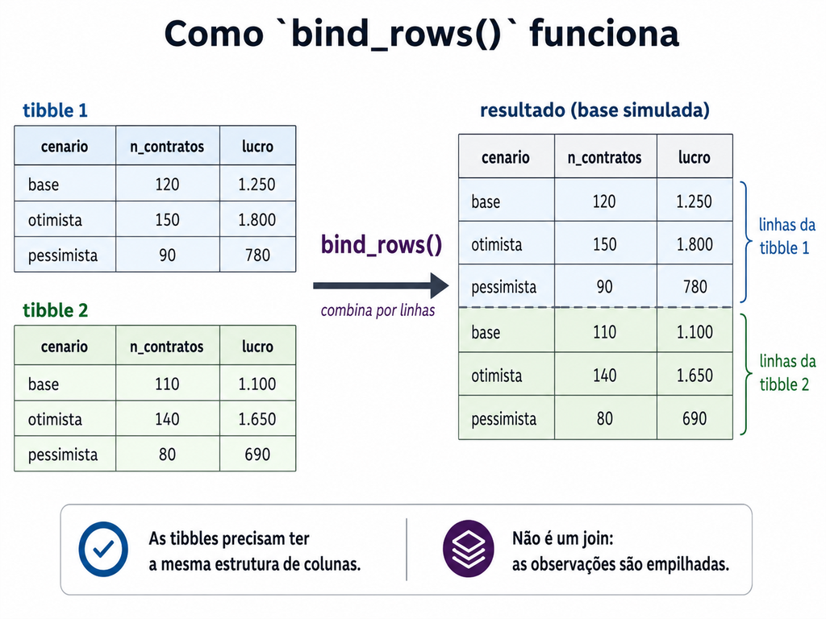

Antes de repetir a função muitas vezes, poderíamos executá-la uma vez para verificar se ela devolve as informações esperadas: cenário, número de contratos, número de inadimplentes e lucro. Na resolução final, porém, vamos diretamente repetir a função 10.000 vezes e organizar os resultados em uma base simulada.

```r
# repete a mesma expressao 10.000 vezes
# simplify = FALSE mantem cada tibble como um elemento de uma lista
resultados_lista <- replicate(
  10000,
  simular_mes(),
  simplify = FALSE
)

# junta a lista de tibbles em uma unica base de dados
# cada linha representa um mes simulado
resultados_simulados <- bind_rows(resultados_lista)

# calcula e exibe as estatisticas gerais
valor_esperado_lucro_mensal <- mean(resultados_simulados$lucro)
valor_esperado_lucro_mensal
```

```
[1] 12661
```

```r
desvio_padrao_lucro_mensal <- sd(resultados_simulados$lucro)
desvio_padrao_lucro_mensal
```

```
[1] 10678
```

```r
covariancia_inadimplencia_lucro <-
  cov(resultados_simulados$n_inadimplentes, resultados_simulados$lucro)
covariancia_inadimplencia_lucro
```

```
[1] -21022
```

```r
correlacao_inadimplencia_lucro <-
  cor(resultados_simulados$n_inadimplentes, resultados_simulados$lucro)
correlacao_inadimplencia_lucro
```

```
[1] -0.8323
```

```r
probabilidade_lucro_negativo <- mean(resultados_simulados$lucro < 0)
probabilidade_lucro_negativo
```

```
[1] 0.1225
```

```r
# agrupa os meses simulados por cenario e calcula o lucro medio de cada grupo
lucros_medios_por_cenario <- resultados_simulados |>
  group_by(cenario) |>
  summarise(
    valor_esperado_lucro = mean(lucro)
  )

lucros_medios_por_cenario
```

```
# A tibble: 3 × 2
  cenario  valor_esperado_lucro
  <chr>                   <dbl>
1 aquecido               25752.
2 fraco                   1041.
3 normal                 11860.
```

Na tabela `lucros_medios_por_cenario`, cada linha mostra o lucro esperado da operação quando fixamos um cenário específico. Em outras palavras, trata-se do valor esperado do lucro **condicional** ao cenário.

Como esperado, a covariância e a correlação entre número de inadimplentes e lucro mensal são negativas. Dentro de um mesmo cenário, isto é, mantendo fixo o número de contratos e a probabilidade de inadimplência, cada inadimplência substitui um contrato lucrativo por uma perda, reduzindo o lucro total do mês.

Este exercício combina duas camadas de incerteza. Primeiro, geramos uma amostra pseudoaleatória de tamanho 1 para o cenário do mês; depois, **condicionalmente** ao cenário simulado, geramos uma amostra pseudoaleatória dos resultados de inadimplência dos contratos. Por isso, o lucro mensal depende tanto do volume de contratos quanto da taxa de inadimplência condicional ao cenário.

A covariância e a correlação calculadas acima são medidas incondicionais: elas usam todos os meses simulados ao mesmo tempo. Por isso, combinam dois efeitos: a relação mecânica negativa entre inadimplência e lucro dentro de cada cenário e a variação entre cenários, que altera simultaneamente o número de contratos e a probabilidade de inadimplência. O resumo por cenário ajuda a separar essas fontes de variação.